# Topic model

Kang

## 简介

可用两种方法进行主题分析：tidytext（以下简称"T"方法）和quanteda（以下简称"Q"方法）。但是两者分析出来的结果有一定差异，此处记录这些差异。

## 目标主题数

目标主题数同样通过基尼系数的突变来判断。其中，T结果如下。突变点为7，且之后基尼系数又逐渐减少，因此最佳主题数为7。

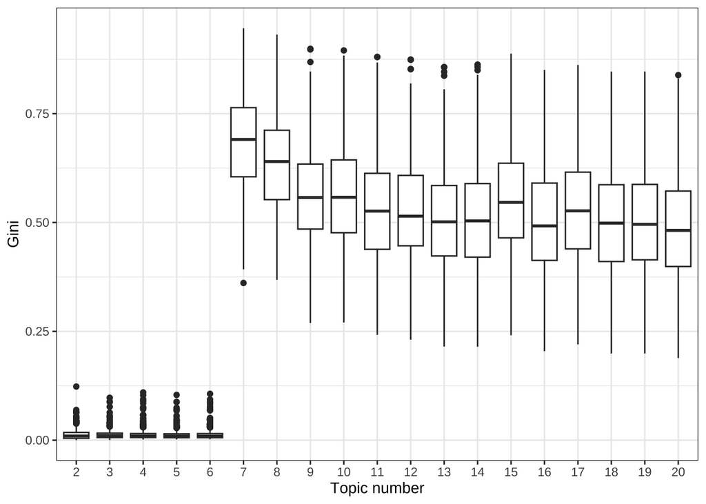

```r
id_topic_test %>%
  group_by(k, id) %>%
  summarise(gini = Gini(gamma)) %>%
  ungroup() %>%
  mutate(k = factor(k, levels = as.character(range_k))) %>%
  ggplot() +
  geom_boxplot(aes(k, gini)) +
  theme_bw() +
  labs(x = "Topic number", y = "Gini")
```

Q主题结果如下，结果类似，最佳主题数为7。

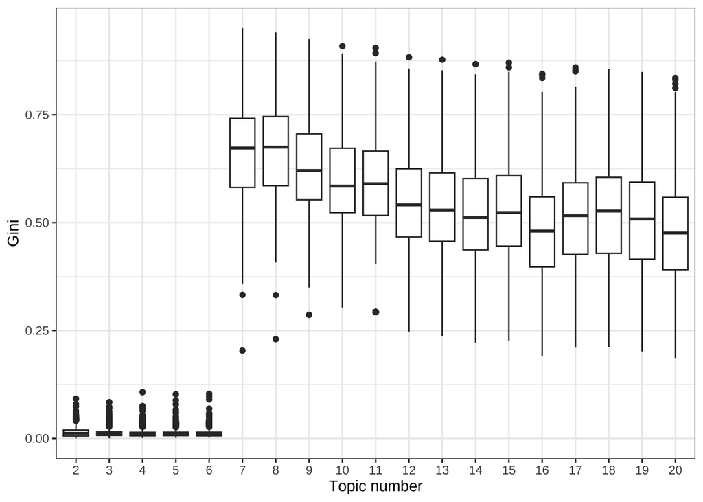

```r
quan_id_topic_test %>%
  group_by(k, id) %>%
  summarise(gini = Gini(gamma), .groups = "drop") %>%
  mutate(k = factor(k, levels = as.character(range_k))) %>%
  ggplot() +
  geom_boxplot(aes(k, gini)) +
  theme_bw() +
  labs(x = "Topic number", y = "Gini")
```

## 各主题关键词

T方法下7个主题的前15位关键词提取如下。需要说明一下这个结果之后可能会微调，因为我的停止词设置还有些小问题。

```r
library(knitr)
library(kableExtra)
tidy(lda, matrix = "beta") %>%
  group_by(topic) %>%
  slice_max(beta, n = 15) %>%
  mutate(term = reorder_within(term, beta, topic)) %>%
  summarise(term = list(term), .groups = "drop") %>%
  mutate(
    term = unlist(lapply(term, function(x) paste0(x, collapse = ", ")))
  ) %>%
  mutate(term = gsub("_", "", term), term = gsub("[0-9]", "", term)) %>%
  kable() %>%
  kable_styling()
```

| topic | term |
| --- | --- |
| 1 | 駆除, 増え, 活用, すぎ, 有効, 良い, 食用, できる, 利用, 必要, シカ, ほうが, もの, 仕方, 頂く \| |
| 2 | 食べる, 鹿, ジビエ, 数, 必要, 良い, 殺, シカ, もの, 気, 肉, 食糧, 食用, イメージ, 栄養 \| |
| 3 | 食肉, シカ, 肉, 人, いい, 動物, たく, 悪い, にし, 他の, 鹿肉, そう, 特に, 聞, 利用 \| |
| 4 | よい, 人間, 自然, 食料, よく, 問題, 害, 考える, なので, ジビエ, ほしい, 方法, 獣, 一つ, 食材 \| |
| 5 | 食, べた, 思, 牛, 豚, 美味, 美味しい, しく, おい, いと, とも, 鶏, イノシシ, 同様, あまり \| |
| 6 | 命, 良い, ただ, 方, 無駄, おいしい, いい, 考え, シカ, いただく, 殺す, 場合, かも, 駆除, 大切 \| |
| 7 | 活用, 的, 食肉, 良い, ジビエ, 資源, 狩猟, 文化, 抵抗, バランス, 有効, 減らす, つながる, 死, のみ, 反対, 安楽, 農地 \| |

Q主题关键词如下。

```r
tidy(quan_lda, matrix = "beta") %>%
  group_by(topic) %>%
  slice_max(beta, n = 15) %>%
  mutate(term = reorder_within(term, beta, topic)) %>%
  summarise(term = list(term), .groups = "drop") %>%
  mutate(
    term = unlist(lapply(term, function(x) paste0(x, collapse = ", ")))
  ) %>%
  mutate(term = gsub("_", "", term), term = gsub("[0-9]", "", term)) %>%
  kable() %>%
  kable_styling()
```

| topic | term |
| --- | --- |
| 1 | よい, 処分, 鹿肉, 悪い, 仕方, 良い, 害, たく, なので, 殺, ジビエ, 生命, バランス, いい, 犬, 獣 \| |
| 2 | 活用, 駆除, 命, 有効, 良い, 無駄, ただ, ほうが, できる, もの, 食用, 資源, 大切, 頂く, 必要 \| |
| 3 | ジビエ, 食べる, おいしい, あまり, 自然, 肉, いただく, 好き, もの, 気, 味, シカ, よく, 抵抗, 知 \| |
| 4 | シカ, 食肉, いい, 数, かも, 必要, 他の, 肉, かわいそう, しまう, 個体, 特に, 思, 聞, なか, 出, 一定 \| |
| 5 | 食, べた, 思, 美味しい, 問題, いと, とも, 肉, 処理, 鹿, 食材, 考える, 言, 文化, 寄生虫, 個人 \| |
| 6 | 利用, 方, 牛, 人, 良い, 豚, 美味, しく, 食肉, 考え, おい, にし, 場合, ことに, 動物 \| |
| 7 | 増え, すぎ, 良い, 鹿, 人間, 殺す, 必要, 食用, 的, 食料, できる, ほしい, シカ, 自然, 野生 \| |

## 各主题典型原文

抽出各个主题下的若干文档原文。正如之前介绍的，某个回答文档通常并非完全属于某个主题，也就是说，就像我们日常说话一样，每个回答都包含了不止一个主题，它可能80%和主题1相关，15%和主题2相关，剩下5%在谈论主题3。所以在这里，我实际上是抽出各个主题下，和该主题最相关的几条回答文档。

T方法下典型原文如下：

```r
id_topic %>%
  group_by(topic) %>%
  arrange(topic, -gamma) %>%
  slice_head(n = 10) %>%
  ungroup() %>%
  # 漏洞：需要提前更改id的类型。
  left_join(mutate(survey, id = as.character(id)), by = "id") %>%
  select(id, topic, ven_reason) %>%
  kable() %>%
  kable_styling()
```

| id | topic | ven_reason |
| --- | --- | --- |
| 389 | 1 | 単に駆除するのではなく有効利用するべきだと思う。駆除するのも費用がかかると思うので、必要な駆除が進むと思う \| |
| 312 | 1 | 駆除したシカは食用に活用して駆除費用などに当てるのが良い \| |
| 30 | 1 | 最初から食用と割り切るならＯＫ。増えてしまったシカを安易に食用として片づけるのはいかがなものか。ジビエがあまり好きではない。 \| |
| 746 | 1 | 増えすぎているのなら、駆除するのも仕方ないと思うので、有効活用になるのでは。 \| |
| 522 | 1 | 有効活用だと思う。レアな感じがして面白い。 \| |
| 203 | 1 | 仕方なく駆除されるものもありえるので有効活用をするべきと思います \| |
| 476 | 1 | 増えすぎて困っているのであれば食用として活用するのも選択肢になると思う \| |
| 619 | 1 | 自然界に生息し、増えすぎている分を駆除するために良いと思う \| |
| 463 | 1 | シカが増えすぎているなら、有効活用するのは良いのでは。 \| |
| 568 | 1 | 場面によるがわざわざ殺生する必要性を感じないため \| |
| 157 | 2 | 栄養が豊富で良いイメージ。買える場所が少ないからわからない。ネットで取り寄せている。気軽に身近に帰ると嬉しい。 \| |
| 105 | 2 | 数十年前にはコース料理でジビエがあれ牛肉に偏向してもらっていた。今後懸念される食糧危機対策になる可能性がある \| |
| 445 | 2 | 鹿である必要もないし、野生の鹿の肉が病原菌などに犯されていないか心配 \| |
| 583 | 2 | 鹿が悪影響を与えているのなら、単純に数を減らせると思うから \| |
| 566 | 2 | 人間の都合によって殺されていい生き物なんていない。良いと思うのならそれは神に対する冒涜だ！動物たちがなにをしたというんだ？ \| |
| 758 | 2 | シカが増えすぎ駆除だけされるなら、みんなにも食してもらい現状を知ってもらうべきだ。牛肉、とり、豚だけなく自然の中にあるお肉を食べるのともっと身近になるのは、良いかと思う。ユーロッパなどはジビエを食べるけど、日本人は、身近でない気がする。飲食店と協力してジビエをもっとしゅうちして身近なものに。 \| |
| 51 | 2 | 間引く意味を込めて良いと思う \| |
| 361 | 2 | シカが食べるものという意識がないから \| |
| 253 | 2 | 人間のテリトリーに入ってきた鹿は活用すべき。鹿の数はコントロールするべきで淘汰した鹿は食用にした方が良い \| |
| 549 | 2 | シカによる、生活においての問題があると思う。その為、一定数の駆除は必要です。 \| |
| 540 | 3 | 好む人はいるし、可愛そうと思う人もいるし。でもどの動物も全てそうだと思うから \| |
| 197 | 3 | 食肉にして活用することは悪くないと思いますが、ビジネスとして高く取り扱われると悪いことに利用し、シカが絶滅するかもしれない。 \| |
| 755 | 3 | 何回か頂き、調理、処理によっては、肩ロースなど最高の食材で、近くにジビエのレストランもある。悪い事ではないと思う。 \| |
| 70 | 3 | 北海道のシカやクマの肉が提供されている \| |
| 356 | 3 | 食肉にすることでシカの増加を抑えられるならいいと思う \| |
| 541 | 3 | うちは、家庭犬がいます。食事は、鹿肉を与えております。ありがたく命を頂いております。 \| |
| 379 | 3 | 他の動物の食肉もあり、シカの肉を無駄なく利用すればいいと思う。鹿肉はヘルシーと聞いている。 \| |
| 694 | 3 | しっかり火を通せば大丈夫 \| |
| 555 | 3 | やり過ぎで絶滅させない限りはアリだと思う \| |
| 712 | 3 | 生態系を守るため、増えすぎた野生動物等に限り良いのではないかと思います。特に鹿肉は、低脂肪で鉄分やビタミンが豊富にあると聞いたことがあるため \| |
| 586 | 4 | 今、話題になるジビエはただ捕獲してほかすのではどうかと思う。それもいいけど。犬、猫の餌に加工するとか動物園の肉食獣の餌にすればよいのでは。こういうことは余り公にならないようにすればよいのではある団体がうるさいし。 \| |
| 54 | 4 | できれば野生で暮らしてほしい。人間が自然を破壊することが原因では。人間都合の自然や社会が生態系を壊していて今後が心配です。 \| |
| 320 | 4 | メリット、デメリットそれぞれあるため。地方での先行事例で成功例をあまり聞かないため。 \| |
| 546 | 4 | 適切な生存個数が算定されているのであれば、その範囲での捕獲で対応すればよいと思う \| |
| 377 | 4 | ニホンジカ急増の問題への解決方法の一つになるのでは？ \| |
| 65 | 4 | 我々人間は動植物の生をいただき生息しているから、自然なことだと思う \| |
| 677 | 4 | ただむやみに殺生するよりは、最後まで責任を全うするのは良いと思う。以前、ＴＶのニュースで見たが、動物園などの食料通るのも一つの方策だと思う \| |
| 547 | 4 | テレビでよくジビエのおいしさを自慢する店があるが鹿を好きな子供足りの夢をぶち壊すことになる。 \| |
| 450 | 4 | 料理方法にもよります。生でしたら、挑戦したくないです。 \| |
| 611 | 4 | 食材として活用することでプラス方向での問題解決が計れるのではないかと思う。鹿皮の活用も同時に考える。（子供の頃、鹿の皮のカバンや廃ブトンが身近にあった）やわらかくて良かった。 \| |
| 358 | 5 | 別に食べたくないから（山奥まで旅行してわざわざジビエを食べに行くことはあっても、日常生活で鹿肉を食べたくなる動機がないから。） \| |
| 705 | 5 | 食べたいと思わない、単に食すイメージもなく、美味しそうとも思わないから \| |
| 335 | 5 | 自然界の回りだから。食べたり、食べられたり。 \| |
| 49 | 5 | 美味しければ食べたい。エゾシカはうまい。 \| |
| 318 | 5 | 1度食べたことがあるが、美味しいと思えない \| |
| 234 | 5 | 食べたことはないが食べたいとも思わないので \| |
| 137 | 5 | 色々の栄養素があるので工夫1つでおいしくなる。 \| |
| 373 | 5 | 以前食べたことがあるが、臭みがあり美味しいと思えない \| |
| 478 | 5 | 植物園で食べたとき美味しかった \| |
| 539 | 5 | 豚肉や牛肉で十分すぎる。飽食の時代にジビエまで食べたい又は食べようとは思わない。 \| |
| 741 | 6 | 生命を奪う代わりに、すべての部位を余すことなく料理し、生命に感謝を捧げる。 \| |
| 344 | 6 | ただ殺すより命をいただいて供養した方がいいと考えます \| |
| 194 | 6 | 駆除しないですむならそれに越したことはないが、声明をつなげる意味では良いと思う。 \| |
| 281 | 6 | 市民生活に直接悪影響を及ぼす場合は良いと思います。 \| |
| 571 | 6 | 駆除しなければならなかったシカは食べたらいいと思うけれど、シカの生息するところでわざわざシカを狩るのは良くないと思うから。 \| |
| 130 | 6 | シカの命を奪ってしまうだけでは申し訳ないのでその命をいただくことで、人間の命を養ってもっらうことに役立てられるから \| |
| 52 | 6 | 食肉が過熱し市街地に出てくるシカ以外も危険にさらされる可能性が高い。市街地であるという事をシカは理解できない \| |
| 491 | 6 | 頭数を減らした方が良いと思っている。せっかくの命生かされるようにした方が良い \| |
| 472 | 6 | 殺すだけではかわいそうだし命ももったいない \| |
| 607 | 6 | 無意味に殺すよりは頂いた方が良い \| |
| 731 | 7 | 狩猟者高齢化による減少の背景の中、ジビエ活用若い狩猟者が増えることを期待します。 \| |
| 597 | 7 | ジビエを活用することは廃棄物を減らし、また地域活性化にもつなげられるから \| |
| 740 | 7 | 活用という表現とは異なるが、ジビエ文化の導入には抵抗はない。 \| |
| 348 | 7 | 有効活用になりうる（環境面の観点からも） \| |
| 449 | 7 | 森林農地への影響が少なくなり、ジビエ活用により日本への食収入量の減少につながる \| |
| 655 | 7 | 農地等にしかけられたワナに捕まった個体に限るなどの制限は必要 \| |
| 628 | 7 | 商業的価値があるのであれば、流通させれば良いと思う \| |
| 432 | 7 | 何も活用されないなら、何かしらに活用されてさいいれば良い。 \| |
| 342 | 7 | 資源の有効活用につながるため。食肉として流通させる体制づくりが大変だと思うが、確立されたら積極的に食べたい。 \| |
| 177 | 7 | 天然資源のリサイクルの一助と思うので \| |

Q主题结果如下：

```r
quan_id_topic %>%
  group_by(topic) %>%
  arrange(topic, -gamma) %>%
  slice_head(n = 10) %>%
  ungroup() %>%
  # 漏洞：需要提前更改id的类型。
  left_join(mutate(survey, id = as.character(id)), by = "id") %>%
  select(id, topic, ven_reason) %>%
  kable() %>%
  kable_styling()
```

| id | topic | ven_reason |
| --- | --- | --- |
| 586 | 1 | 今、話題になるジビエはただ捕獲してほかすのではどうかと思う。それもいいけど。犬、猫の餌に加工するとか動物園の肉食獣の餌にすればよいのでは。こういうことは余り公にならないようにすればよいのではある団体がうるさいし。 \| |
| 741 | 1 | 生命を奪う代わりに、すべての部位を余すことなく料理し、生命に感謝を捧げる。 \| |
| 546 | 1 | 適切な生存個数が算定されているのであれば、その範囲での捕獲で対応すればよいと思う \| |
| 624 | 1 | 野生動物との共生や獣害についての関心を高められるため \| |
| 541 | 1 | うちは、家庭犬がいます。食事は、鹿肉を与えております。ありがたく命を頂いております。 \| |
| 731 | 1 | 狩猟者高齢化による減少の背景の中、ジビエ活用若い狩猟者が増えることを期待します。 \| |
| 450 | 1 | 料理方法にもよります。生でしたら、挑戦したくないです。 \| |
| 712 | 1 | 生態系を守るため、増えすぎた野生動物等に限り良いのではないかと思います。特に鹿肉は、低脂肪で鉄分やビタミンが豊富にあると聞いたことがあるため \| |
| 755 | 1 | 何回か頂き、調理、処理によっては、肩ロースなど最高の食材で、近くにジビエのレストランもある。悪い事ではないと思う。 \| |
| 10 | 1 | 地球上でバランス好く共存するため \| |
| 235 | 2 | 駆除ができて有効に活用できれば駆除の費用も捻出できそうだし地域の活性にもつながりそう \| |
| 407 | 2 | そもそも食用としている地域での活用はすべき。ただ普及のために不必要な活用には反対 \| |
| 158 | 2 | 駆除しないといけないのなら命をいただいて有効活用すべきと思います。 \| |
| 519 | 2 | ただ駆除されるくらいなら活用されるほうが良いと思う。 \| |
| 223 | 2 | 必要があり駆除されるのであれば命を次につなげるのは大切だと思います \| |
| 522 | 2 | 有効活用だと思う。レアな感じがして面白い。 \| |
| 432 | 2 | 何も活用されないなら、何かしらに活用されてさいいれば良い。 \| |
| 527 | 2 | 駆除されるなら、食用活用されたほうが良い \| |
| 537 | 2 | 駆除、安楽死させるのであれば、命を粗末にするより、頂くほうが良いのかもしれない。 \| |
| 675 | 2 | 駆除や安楽死に反対だから \| |
| 99 | 3 | シカは凶暴なイメージがないので少し可哀想な気がするが、実際ジビエは販売されているから \| |
| 441 | 3 | ジビエは好きですが、安全性が保証されているかが気になる \| |
| 296 | 3 | 自然のものを食べるのは当然（おいしい又は栄養があるなら） \| |
| 105 | 3 | 数十年前にはコース料理でジビエがあれ牛肉に偏向してもらっていた。今後懸念される食糧危機対策になる可能性がある \| |
| 66 | 3 | 赤身肉でおいしいらしいので賛成 \| |
| 70 | 3 | 北海道のシカやクマの肉が提供されている \| |
| 758 | 3 | シカが増えすぎ駆除だけされるなら、みんなにも食してもらい現状を知ってもらうべきだ。牛肉、とり、豚だけなく自然の中にあるお肉を食べるのともっと身近になるのは、良いかと思う。ユーロッパなどはジビエを食べるけど、日本人は、身近でない気がする。飲食店と協力してジビエをもっとしゅうちして身近なものに。 \| |
| 547 | 3 | テレビでよくジビエのおいしさを自慢する店があるが鹿を好きな子供足りの夢をぶち壊すことになる。 \| |
| 363 | 3 | 精神的に食べる気がしない \| |
| 361 | 3 | シカが食べるものという意識がないから \| |
| 52 | 4 | 食肉が過熱し市街地に出てくるシカ以外も危険にさらされる可能性が高い。市街地であるという事をシカは理解できない \| |
| 340 | 4 | スーパーで売っている肉類とシカが特に違うとは思わないから \| |
| 584 | 4 | 生息数の管理のために必要だと思う（オオカミの変わりに） \| |
| 336 | 4 | 市街地近くにいるシカを食肉にするのは少しかわいそう \| |
| 750 | 4 | 安定供給と個体数と食肉価格があまりつりあうとは思えないが、暫定処置としてはありかと \| |
| 356 | 4 | 食肉にすることでシカの増加を抑えられるならいいと思う \| |
| 571 | 4 | 駆除しなければならなかったシカは食べたらいいと思うけれど、シカの生息するところでわざわざシカを狩るのは良くないと思うから。 \| |
| 729 | 4 | 一定数以上の増加であれば、自然界のバランスのためにも通常の事と考える \| |
| 328 | 4 | 食肉にされた状態だと食べてみたいと思うが、生きている状態で聞かれればかわいそうに感じてしまうので。 \| |
| 694 | 4 | しっかり火を通せば大丈夫 \| |
| 611 | 5 | 食材として活用することでプラス方向での問題解決が計れるのではないかと思う。鹿皮の活用も同時に考える。（子供の頃、鹿の皮のカバンや廃ブトンが身近にあった）やわらかくて良かった。 \| |
| 25 | 5 | 嗜好の問題だと思いますが食べたいとは思いません。癖がありそう \| |
| 234 | 5 | 食べたことはないが食べたいとも思わないので \| |
| 373 | 5 | 以前食べたことがあるが、臭みがあり美味しいと思えない \| |
| 244 | 5 | 個人的に食べたいと思わない \| |
| 279 | 5 | 鹿はこんなに可愛いのに、どうして鹿を食べられるの？ \| |
| 318 | 5 | 1度食べたことがあるが、美味しいと思えない \| |
| 538 | 5 | 個人的には食べたいと思わないが、美味しいと感じる人がいるのも理解できる \| |
| 297 | 5 | 羊の肉もあるため悪いとも言えないが食べたいとも思わないため \| |
| 321 | 5 | 滋賀では普通に食べられている \| |
| 186 | 6 | 地元である北海道でもエゾシカを食用にしており、おいしくいただけているため。 \| |
| 237 | 6 | 動物も生きる権利あり無益な殺生と思うから。私は他人の意見です。 \| |
| 495 | 6 | 牛、豚、鳥、イノシシなどの動物と同様と思うから \| |
| 250 | 6 | 食用として飼われているのなら牛や豚などと変わりないと思う \| |
| 39 | 6 | 牛や豚などを食べているので食肉にしても良いと思うが、かわいい姿を見ると心がいたみます。 \| |
| 137 | 6 | 色々の栄養素があるので工夫1つでおいしくなる。 \| |
| 621 | 6 | ただ殺したりするよりは良いと感じたため \| |
| 82 | 6 | やむなく駆除が行われた場合、死体をただ処分するよりは利用できた方が良いと思うから。 \| |
| 482 | 6 | 鹿の食肉に対してのみ否定的な意見を持つことは、普段豚や牛などの肉から栄養を享受させていただいている身として命に差をつけていることになるため。 \| |
| 485 | 6 | ジビエで生計を立てている人もいると思うので、食用については牛や豚と同じ括りのイメージでした。 \| |
| 451 | 7 | 無駄にしないという観点から良いなと思ったこともあったが、人間の勝手な都合のようにも感じる。なぜ野生の鹿が増えすぎてしまったのか、森林や農地に被害をもたらすようになってしまったのか、根本のところを見直して人間もシカも住みやすい環境を整えるのが理想。 \| |
| 677 | 7 | ただむやみに殺生するよりは、最後まで責任を全うするのは良いと思う。以前、ＴＶのニュースで見たが、動物園などの食料通るのも一つの方策だと思う \| |
| 566 | 7 | 人間の都合によって殺されていい生き物なんていない。良いと思うのならそれは神に対する冒涜だ！動物たちがなにをしたというんだ？ \| |
| 682 | 7 | 増え続けると良くない。食用することによって気持ち的に楽かな \| |
| 658 | 7 | 環境の変化によりシカの頭数は増えすぎており積極的な管理が必要。しかし単に殺すのは倫理的ではない。また畜産の環境負荷低減のためにも、野生肉を代替にすることは有効だから。 \| |
| 448 | 7 | 人間に食べられるよりも、寿命を全うできるように自然社会で生きつづけてほしいから \| |
| 54 | 7 | できれば野生で暮らしてほしい。人間が自然を破壊することが原因では。人間都合の自然や社会が生態系を壊していて今後が心配です。 \| |
| 655 | 7 | 農地等にしかけられたワナに捕まった個体に限るなどの制限は必要 \| |
| 754 | 7 | 増えすぎたら、自然のバランスが崩れます。しかし、駆除されゴミとして処理されるのは、あまりにも人間の傲慢さのなせるものと思います。殺すのなら、せめて食用として命のつなぎに \| |
| 210 | 7 | 増えすぎをコントロールする必要から \| |